# Risk Factor Analysis

## Outcome Variable

**Outcome Variable:** whz

## Predictor Variables

**Intervention Variable:** impsan

**Adjustment Set:**

- arm
- sex
- W_mage
- meducyrs
- feducyrs
- hhwealth_quart
- hfoodsec
- W_mhtcm
- W_mwtkg
- W_mbmi
- W_nrooms
- W_nchldlt5
- W_parity
- impfloor
- safeh20
- delta_W_mage
- delta_meducyrs
- delta_feducyrs
- delta_hhwealth_quart
- delta_hfoodsec
- delta_W_mhtcm
- delta_W_mwtkg
- delta_W_mbmi
- delta_W_nrooms
- delta_W_nchldlt5
- delta_W_parity
- delta_impfloor
- delta_safeh20

## Stratifying Variables

The analysis was stratified on these variable(s):

- agecat
- studyid
- country

## Data Summary

| agecat | studyid | country | impsan | n_cell | n |
| --- | --- | --- | --- | --- | --- |
| Birth | COHORTS | GUATEMALA | 1 | 43 | 449 |
| Birth | COHORTS | GUATEMALA | 0 | 406 | 449 |
| Birth | COHORTS | INDIA | 1 | 1685 | 4461 |
| Birth | COHORTS | INDIA | 0 | 2776 | 4461 |
| Birth | COHORTS | PHILIPPINES | 1 | 177 | 1126 |
| Birth | COHORTS | PHILIPPINES | 0 | 949 | 1126 |
| Birth | CONTENT | PERU | 1 | 1 | 2 |
| Birth | CONTENT | PERU | 0 | 1 | 2 |
| Birth | JiVitA-3 | BANGLADESH | 1 | 12413 | 17991 |
| Birth | JiVitA-3 | BANGLADESH | 0 | 5578 | 17991 |
| Birth | JiVitA-4 | BANGLADESH | 1 | 1859 | 2394 |
| Birth | JiVitA-4 | BANGLADESH | 0 | 535 | 2394 |
| Birth | MAL-ED | BANGLADESH | 1 | 168 | 201 |
| Birth | MAL-ED | BANGLADESH | 0 | 33 | 201 |
| Birth | MAL-ED | BRAZIL | 1 | 56 | 57 |
| Birth | MAL-ED | BRAZIL | 0 | 1 | 57 |
| Birth | MAL-ED | INDIA | 1 | 14 | 39 |
| Birth | MAL-ED | INDIA | 0 | 25 | 39 |
| Birth | MAL-ED | NEPAL | 1 | 24 | 25 |
| Birth | MAL-ED | NEPAL | 0 | 1 | 25 |
| Birth | MAL-ED | PERU | 1 | 50 | 203 |
| Birth | MAL-ED | PERU | 0 | 153 | 203 |
| Birth | MAL-ED | SOUTH AFRICA | 1 | 0 | 94 |
| Birth | MAL-ED | SOUTH AFRICA | 0 | 94 | 94 |
| Birth | MAL-ED | TANZANIA, UNITED REPUBLIC OF | 1 | 0 | 110 |
| Birth | MAL-ED | TANZANIA, UNITED REPUBLIC OF | 0 | 110 | 110 |
| Birth | NIH-Birth | BANGLADESH | 1 | 222 | 575 |
| Birth | NIH-Birth | BANGLADESH | 0 | 353 | 575 |
| Birth | NIH-Crypto | BANGLADESH | 1 | 610 | 696 |
| Birth | NIH-Crypto | BANGLADESH | 0 | 86 | 696 |

[output cut: 70 more lines]

The following strata were considered:

- agecat: 24 months, studyid: COHORTS, country: GUATEMALA
- agecat: 24 months, studyid: COHORTS, country: INDIA
- agecat: 24 months, studyid: COHORTS, country: PHILIPPINES
- agecat: 24 months, studyid: CONTENT, country: PERU
- agecat: 24 months, studyid: JiVitA-3, country: BANGLADESH
- agecat: 24 months, studyid: JiVitA-4, country: BANGLADESH
- agecat: 24 months, studyid: LCNI-5, country: MALAWI
- agecat: 24 months, studyid: MAL-ED, country: BANGLADESH
- agecat: 24 months, studyid: MAL-ED, country: BRAZIL
- agecat: 24 months, studyid: MAL-ED, country: INDIA
- agecat: 24 months, studyid: MAL-ED, country: NEPAL
- agecat: 24 months, studyid: MAL-ED, country: PERU
- agecat: 24 months, studyid: MAL-ED, country: SOUTH AFRICA
- agecat: 24 months, studyid: MAL-ED, country: TANZANIA, UNITED REPUBLIC OF
- agecat: 24 months, studyid: NIH-Birth, country: BANGLADESH
- agecat: 24 months, studyid: NIH-Crypto, country: BANGLADESH
- agecat: 24 months, studyid: PROVIDE, country: BANGLADESH
- agecat: 6 months, studyid: COHORTS, country: GUATEMALA
- agecat: 6 months, studyid: COHORTS, country: INDIA
- agecat: 6 months, studyid: COHORTS, country: PHILIPPINES
- agecat: 6 months, studyid: CONTENT, country: PERU
- agecat: 6 months, studyid: JiVitA-3, country: BANGLADESH
- agecat: 6 months, studyid: JiVitA-4, country: BANGLADESH
- agecat: 6 months, studyid: LCNI-5, country: MALAWI
- agecat: 6 months, studyid: MAL-ED, country: BANGLADESH
- agecat: 6 months, studyid: MAL-ED, country: BRAZIL
- agecat: 6 months, studyid: MAL-ED, country: INDIA
- agecat: 6 months, studyid: MAL-ED, country: NEPAL
- agecat: 6 months, studyid: MAL-ED, country: PERU
- agecat: 6 months, studyid: MAL-ED, country: SOUTH AFRICA
- agecat: 6 months, studyid: MAL-ED, country: TANZANIA, UNITED REPUBLIC OF
- agecat: 6 months, studyid: NIH-Birth, country: BANGLADESH
- agecat: 6 months, studyid: NIH-Crypto, country: BANGLADESH
- agecat: 6 months, studyid: PROVIDE, country: BANGLADESH
- agecat: Birth, studyid: COHORTS, country: GUATEMALA
- agecat: Birth, studyid: COHORTS, country: INDIA
- agecat: Birth, studyid: COHORTS, country: PHILIPPINES
- agecat: Birth, studyid: CONTENT, country: PERU
- agecat: Birth, studyid: JiVitA-3, country: BANGLADESH
- agecat: Birth, studyid: JiVitA-4, country: BANGLADESH
- agecat: Birth, studyid: MAL-ED, country: BANGLADESH
- agecat: Birth, studyid: MAL-ED, country: BRAZIL
- agecat: Birth, studyid: MAL-ED, country: INDIA
- agecat: Birth, studyid: MAL-ED, country: NEPAL
- agecat: Birth, studyid: MAL-ED, country: PERU
- agecat: Birth, studyid: MAL-ED, country: SOUTH AFRICA
- agecat: Birth, studyid: MAL-ED, country: TANZANIA, UNITED REPUBLIC OF
- agecat: Birth, studyid: NIH-Birth, country: BANGLADESH
- agecat: Birth, studyid: NIH-Crypto, country: BANGLADESH
- agecat: Birth, studyid: PROVIDE, country: BANGLADESH

### Dropped Strata

Some strata were dropped due to rare outcomes:

- agecat: Birth, studyid: CONTENT, country: PERU
- agecat: Birth, studyid: MAL-ED, country: BRAZIL
- agecat: Birth, studyid: MAL-ED, country: NEPAL
- agecat: Birth, studyid: MAL-ED, country: SOUTH AFRICA
- agecat: Birth, studyid: MAL-ED, country: TANZANIA, UNITED REPUBLIC OF
- agecat: Birth, studyid: PROVIDE, country: BANGLADESH
- agecat: 6 months, studyid: LCNI-5, country: MALAWI
- agecat: 6 months, studyid: MAL-ED, country: BRAZIL
- agecat: 6 months, studyid: MAL-ED, country: NEPAL
- agecat: 6 months, studyid: MAL-ED, country: SOUTH AFRICA
- agecat: 6 months, studyid: MAL-ED, country: TANZANIA, UNITED REPUBLIC OF
- agecat: 6 months, studyid: PROVIDE, country: BANGLADESH
- agecat: 24 months, studyid: LCNI-5, country: MALAWI
- agecat: 24 months, studyid: MAL-ED, country: BRAZIL
- agecat: 24 months, studyid: MAL-ED, country: NEPAL
- agecat: 24 months, studyid: MAL-ED, country: SOUTH AFRICA
- agecat: 24 months, studyid: MAL-ED, country: TANZANIA, UNITED REPUBLIC OF
- agecat: 24 months, studyid: PROVIDE, country: BANGLADESH

## Methods Detail

We’re interested in the causal parameters $E[Y_a]$ for all values of $a \in \mathcal{A}$. These parameters represent the mean outcome if, possibly contrary to fact, we intervened to set all units to have $A=a$. Under the randomization and positivity assumptions, these are identified by the statistical parameters $\psi_a=E_W[E_{Y|A,W}(Y|A=a,W)]$. In addition, we’re interested in the mean of $Y$, $E[Y]$ under no intervention (the observed mean). We will estimate these parameters by using SuperLearner to fit the relevant likelihood factors – $E_{Y|A,W}(Y|A=a,W)$ and $p(A=a|W)$, and then updating our likelihood fit using a joint TMLE.

For unadjusted analyses ($W=\{\}$), initial likelihoods were estimated using Lrnr_glm to estimate the simple $E(Y|A)$ and Lrnr_mean to estimate $p(A)$. For adjusted analyses, a small library containing Lrnr_glmnet, Lrnr_xgboost, and Lrnr_mean was used.

# Results Detail

## Results Plots

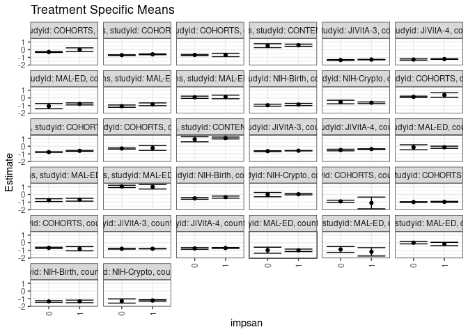

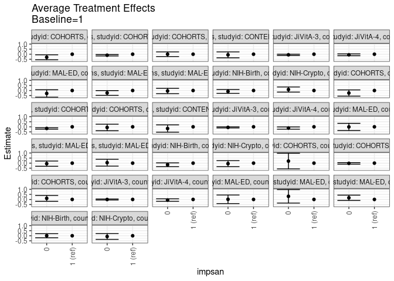

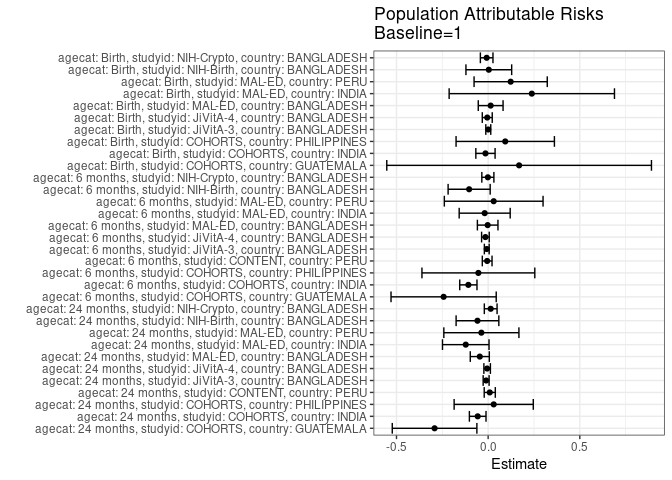

## Results Table

### Parameter: TSM

| agecat | studyid | country | intervention_level | baseline_level | estimate | ci_lower | ci_upper |
| --- | --- | --- | --- | --- | --- | --- | --- |
| Birth | COHORTS | GUATEMALA | 1 | NA | -1.0983798 | -1.8573826 | -0.3393769 |
| Birth | COHORTS | GUATEMALA | 0 | NA | -0.8953577 | -1.0393914 | -0.7513239 |
| Birth | COHORTS | INDIA | 1 | NA | -0.9625336 | -1.0269437 | -0.8981235 |
| Birth | COHORTS | INDIA | 0 | NA | -0.9849076 | -1.0296473 | -0.9401679 |
| Birth | COHORTS | PHILIPPINES | 1 | NA | -0.7773514 | -1.0519297 | -0.5027731 |
| Birth | COHORTS | PHILIPPINES | 0 | NA | -0.6691320 | -0.7555256 | -0.5827384 |
| Birth | JiVitA-3 | BANGLADESH | 1 | NA | -0.7784707 | -0.8030496 | -0.7538918 |
| Birth | JiVitA-3 | BANGLADESH | 0 | NA | -0.7835336 | -0.8294015 | -0.7376657 |
| Birth | JiVitA-4 | BANGLADESH | 1 | NA | -0.6834099 | -0.7424846 | -0.6243353 |
| Birth | JiVitA-4 | BANGLADESH | 0 | NA | -0.7426269 | -0.8502688 | -0.6349851 |
| Birth | MAL-ED | BANGLADESH | 1 | NA | -0.9865689 | -1.1487586 | -0.8243793 |
| Birth | MAL-ED | BANGLADESH | 0 | NA | -0.9713964 | -1.3613830 | -0.5814099 |
| Birth | MAL-ED | INDIA | 1 | NA | -1.1822786 | -1.7244366 | -0.6401206 |
| Birth | MAL-ED | INDIA | 0 | NA | -0.8752066 | -1.2512596 | -0.4991536 |
| Birth | MAL-ED | PERU | 1 | NA | -0.1609524 | -0.3743944 | 0.0524896 |
| Birth | MAL-ED | PERU | 0 | NA | 0.0019036 | -0.1511974 | 0.1550046 |
| Birth | NIH-Birth | BANGLADESH | 1 | NA | -1.3535147 | -1.5183290 | -1.1887004 |
| Birth | NIH-Birth | BANGLADESH | 0 | NA | -1.3523184 | -1.4700345 | -1.2346024 |
| Birth | NIH-Crypto | BANGLADESH | 1 | NA | -1.2322291 | -1.3217361 | -1.1427222 |
| Birth | NIH-Crypto | BANGLADESH | 0 | NA | -1.3056356 | -1.5795554 | -1.0317158 |
| 6 months | COHORTS | GUATEMALA | 1 | NA | 0.3887559 | 0.0934855 | 0.6840262 |
| 6 months | COHORTS | GUATEMALA | 0 | NA | 0.1408458 | 0.0492386 | 0.2324530 |
| 6 months | COHORTS | INDIA | 1 | NA | -0.6024996 | -0.6586191 | -0.5463802 |
| 6 months | COHORTS | INDIA | 0 | NA | -0.7639339 | -0.8064999 | -0.7213679 |
| 6 months | COHORTS | PHILIPPINES | 1 | NA | -0.2297080 | -0.5438699 | 0.0844539 |
| 6 months | COHORTS | PHILIPPINES | 0 | NA | -0.2941656 | -0.3691882 | -0.2191430 |
| 6 months | CONTENT | PERU | 1 | NA | 1.0697584 | 0.9467959 | 1.1927210 |
| 6 months | CONTENT | PERU | 0 | NA | 0.9025423 | 0.5681168 | 1.2369678 |
| 6 months | JiVitA-3 | BANGLADESH | 1 | NA | -0.5855473 | -0.6097621 | -0.5613324 |
| 6 months | JiVitA-3 | BANGLADESH | 0 | NA | -0.6424914 | -0.6930619 | -0.5919208 |
| 6 months | JiVitA-4 | BANGLADESH | 1 | NA | -0.3752557 | -0.4177575 | -0.3327539 |
| 6 months | JiVitA-4 | BANGLADESH | 0 | NA | -0.4954450 | -0.5997921 | -0.3910979 |
| 6 months | MAL-ED | BANGLADESH | 1 | NA | -0.1307434 | -0.2717777 | 0.0102909 |
| 6 months | MAL-ED | BANGLADESH | 0 | NA | -0.1404321 | -0.4668374 | 0.1859731 |
| 6 months | MAL-ED | INDIA | 1 | NA | -0.6829104 | -0.8672013 | -0.4986194 |
| 6 months | MAL-ED | INDIA | 0 | NA | -0.7348181 | -0.9124927 | -0.5571434 |
| 6 months | MAL-ED | PERU | 1 | NA | 1.0070591 | 0.7138155 | 1.3003026 |
| 6 months | MAL-ED | PERU | 0 | NA | 1.0499418 | 0.8987955 | 1.2010880 |
| 6 months | NIH-Birth | BANGLADESH | 1 | NA | -0.3437276 | -0.4836312 | -0.2038240 |
| 6 months | NIH-Birth | BANGLADESH | 0 | NA | -0.5054707 | -0.6245353 | -0.3864061 |
| 6 months | NIH-Crypto | BANGLADESH | 1 | NA | 0.0352561 | -0.0480948 | 0.1186069 |
| 6 months | NIH-Crypto | BANGLADESH | 0 | NA | -0.0153037 | -0.2969238 | 0.2663165 |
| 24 months | COHORTS | GUATEMALA | 1 | NA | 0.0060547 | -0.2285197 | 0.2406292 |
| 24 months | COHORTS | GUATEMALA | 0 | NA | -0.2979554 | -0.3612315 | -0.2346792 |
| 24 months | COHORTS | INDIA | 1 | NA | -0.6036874 | -0.6600972 | -0.5472776 |
| 24 months | COHORTS | INDIA | 0 | NA | -0.7057661 | -0.7491115 | -0.6624208 |
| 24 months | COHORTS | PHILIPPINES | 1 | NA | -0.6867411 | -0.9064120 | -0.4670702 |
| 24 months | COHORTS | PHILIPPINES | 0 | NA | -0.6888221 | -0.7593095 | -0.6183348 |
| 24 months | CONTENT | PERU | 1 | NA | 0.5814482 | 0.4372173 | 0.7256792 |
| 24 months | CONTENT | PERU | 0 | NA | 0.5176200 | 0.2644338 | 0.7708061 |
| 24 months | JiVitA-3 | BANGLADESH | 1 | NA | -1.2860518 | -1.3147750 | -1.2573287 |
| 24 months | JiVitA-3 | BANGLADESH | 0 | NA | -1.3460396 | -1.4021578 | -1.2899215 |
| 24 months | JiVitA-4 | BANGLADESH | 1 | NA | -1.2176588 | -1.2542938 | -1.1810239 |
| 24 months | JiVitA-4 | BANGLADESH | 0 | NA | -1.2779257 | -1.3625147 | -1.1933368 |
| 24 months | MAL-ED | BANGLADESH | 1 | NA | -0.7737092 | -0.9044148 | -0.6430035 |
| 24 months | MAL-ED | BANGLADESH | 0 | NA | -1.0648310 | -1.4043850 | -0.7252770 |
| 24 months | MAL-ED | INDIA | 1 | NA | -0.8268439 | -1.0072354 | -0.6464524 |
| 24 months | MAL-ED | INDIA | 0 | NA | -1.0681176 | -1.2169821 | -0.9192532 |
| 24 months | MAL-ED | PERU | 1 | NA | 0.1341807 | -0.0954414 | 0.3638027 |
| 24 months | MAL-ED | PERU | 0 | NA | 0.0892369 | -0.0553575 | 0.2338313 |
| 24 months | NIH-Birth | BANGLADESH | 1 | NA | -0.8533138 | -0.9974231 | -0.7092044 |
| 24 months | NIH-Birth | BANGLADESH | 0 | NA | -0.9437823 | -1.0735382 | -0.8140263 |
| 24 months | NIH-Crypto | BANGLADESH | 1 | NA | -0.6254975 | -0.7305630 | -0.5204320 |
| 24 months | NIH-Crypto | BANGLADESH | 0 | NA | -0.5288950 | -0.7596281 | -0.2981620 |

### Parameter: E(Y)

| agecat | studyid | country | intervention_level | baseline_level | estimate | ci_lower | ci_upper |
| --- | --- | --- | --- | --- | --- | --- | --- |
| Birth | COHORTS | GUATEMALA | NA | NA | -0.9294432 | -1.0701697 | -0.7887168 |
| Birth | COHORTS | INDIA | NA | NA | -0.9771733 | -1.0119896 | -0.9423570 |
| Birth | COHORTS | PHILIPPINES | NA | NA | -0.6841030 | -0.7582767 | -0.6099293 |
| Birth | JiVitA-3 | BANGLADESH | NA | NA | -0.7777528 | -0.7967725 | -0.7587330 |
| Birth | JiVitA-4 | BANGLADESH | NA | NA | -0.6882498 | -0.7406539 | -0.6358456 |
| Birth | MAL-ED | BANGLADESH | NA | NA | -0.9728358 | -1.1217009 | -0.8239707 |
| Birth | MAL-ED | INDIA | NA | NA | -0.9441026 | -1.2397919 | -0.6484132 |
| Birth | MAL-ED | PERU | NA | NA | -0.0381281 | -0.1669868 | 0.0907307 |
| Birth | NIH-Birth | BANGLADESH | NA | NA | -1.3499217 | -1.4444634 | -1.2553801 |
| Birth | NIH-Crypto | BANGLADESH | NA | NA | -1.2402802 | -1.3249395 | -1.1556208 |
| 6 months | COHORTS | GUATEMALA | NA | NA | 0.1458511 | 0.0589571 | 0.2327450 |
| 6 months | COHORTS | INDIA | NA | NA | -0.7104855 | -0.7428053 | -0.6781657 |
| 6 months | COHORTS | PHILIPPINES | NA | NA | -0.2830286 | -0.3471028 | -0.2189545 |
| 6 months | CONTENT | PERU | NA | NA | 1.0644279 | 0.9468682 | 1.1819876 |
| 6 months | JiVitA-3 | BANGLADESH | NA | NA | -0.5931476 | -0.6127125 | -0.5735828 |
| 6 months | JiVitA-4 | BANGLADESH | NA | NA | -0.3901595 | -0.4274150 | -0.3529041 |
| 6 months | MAL-ED | BANGLADESH | NA | NA | -0.1333333 | -0.2623761 | -0.0042906 |
| 6 months | MAL-ED | INDIA | NA | NA | -0.7018062 | -0.8289790 | -0.5746333 |
| 6 months | MAL-ED | PERU | NA | NA | 1.0372972 | 0.9141109 | 1.1604836 |
| 6 months | NIH-Birth | BANGLADESH | NA | NA | -0.4474038 | -0.5378167 | -0.3569909 |
| 6 months | NIH-Crypto | BANGLADESH | NA | NA | 0.0336790 | -0.0458848 | 0.1132428 |
| 24 months | COHORTS | GUATEMALA | NA | NA | -0.2861905 | -0.3461594 | -0.2262216 |
| 24 months | COHORTS | INDIA | NA | NA | -0.6606874 | -0.6938402 | -0.6275347 |
| 24 months | COHORTS | PHILIPPINES | NA | NA | -0.6564149 | -0.7144543 | -0.5983756 |
| 24 months | CONTENT | PERU | NA | NA | 0.5902439 | 0.4560143 | 0.7244735 |
| 24 months | JiVitA-3 | BANGLADESH | NA | NA | -1.2970418 | -1.3203361 | -1.2737475 |
| 24 months | JiVitA-4 | BANGLADESH | NA | NA | -1.2231776 | -1.2550332 | -1.1913220 |
| 24 months | MAL-ED | BANGLADESH | NA | NA | -0.8192925 | -0.9412667 | -0.6973182 |
| 24 months | MAL-ED | INDIA | NA | NA | -0.9490222 | -1.0651720 | -0.8328724 |
| 24 months | MAL-ED | PERU | NA | NA | 0.0972406 | -0.0271085 | 0.2215898 |
| 24 months | NIH-Birth | BANGLADESH | NA | NA | -0.9115790 | -1.0095022 | -0.8136559 |
| 24 months | NIH-Crypto | BANGLADESH | NA | NA | -0.6115706 | -0.7075788 | -0.5155624 |

### Parameter: ATE

| agecat | studyid | country | intervention_level | baseline_level | estimate | ci_lower | ci_upper |
| --- | --- | --- | --- | --- | --- | --- | --- |
| Birth | COHORTS | GUATEMALA | 1 | 1 | 0.0000000 | 0.0000000 | 0.0000000 |
| Birth | COHORTS | GUATEMALA | 0 | 1 | 0.2030221 | -0.5688812 | 0.9749254 |
| Birth | COHORTS | INDIA | 1 | 1 | 0.0000000 | 0.0000000 | 0.0000000 |
| Birth | COHORTS | INDIA | 0 | 1 | -0.0223740 | -0.1006712 | 0.0559232 |
| Birth | COHORTS | PHILIPPINES | 1 | 1 | 0.0000000 | 0.0000000 | 0.0000000 |
| Birth | COHORTS | PHILIPPINES | 0 | 1 | 0.1082194 | -0.1795958 | 0.3960346 |
| Birth | JiVitA-3 | BANGLADESH | 1 | 1 | 0.0000000 | 0.0000000 | 0.0000000 |
| Birth | JiVitA-3 | BANGLADESH | 0 | 1 | -0.0050629 | -0.0549870 | 0.0448612 |
| Birth | JiVitA-4 | BANGLADESH | 1 | 1 | 0.0000000 | 0.0000000 | 0.0000000 |
| Birth | JiVitA-4 | BANGLADESH | 0 | 1 | -0.0592170 | -0.1820561 | 0.0636221 |
| Birth | MAL-ED | BANGLADESH | 1 | 1 | 0.0000000 | 0.0000000 | 0.0000000 |
| Birth | MAL-ED | BANGLADESH | 0 | 1 | 0.0151725 | -0.4085772 | 0.4389222 |
| Birth | MAL-ED | INDIA | 1 | 1 | 0.0000000 | 0.0000000 | 0.0000000 |
| Birth | MAL-ED | INDIA | 0 | 1 | 0.3070720 | -0.3594806 | 0.9736246 |
| Birth | MAL-ED | PERU | 1 | 1 | 0.0000000 | 0.0000000 | 0.0000000 |
| Birth | MAL-ED | PERU | 0 | 1 | 0.1628560 | -0.0997680 | 0.4254800 |
| Birth | NIH-Birth | BANGLADESH | 1 | 1 | 0.0000000 | 0.0000000 | 0.0000000 |
| Birth | NIH-Birth | BANGLADESH | 0 | 1 | 0.0011963 | -0.2015555 | 0.2039481 |
| Birth | NIH-Crypto | BANGLADESH | 1 | 1 | 0.0000000 | 0.0000000 | 0.0000000 |
| Birth | NIH-Crypto | BANGLADESH | 0 | 1 | -0.0734065 | -0.3625756 | 0.2157626 |
| 6 months | COHORTS | GUATEMALA | 1 | 1 | 0.0000000 | 0.0000000 | 0.0000000 |
| 6 months | COHORTS | GUATEMALA | 0 | 1 | -0.2479101 | -0.5560308 | 0.0602107 |
| 6 months | COHORTS | INDIA | 1 | 1 | 0.0000000 | 0.0000000 | 0.0000000 |
| 6 months | COHORTS | INDIA | 0 | 1 | -0.1614343 | -0.2317192 | -0.0911494 |
| 6 months | COHORTS | PHILIPPINES | 1 | 1 | 0.0000000 | 0.0000000 | 0.0000000 |
| 6 months | COHORTS | PHILIPPINES | 0 | 1 | -0.0644576 | -0.3877983 | 0.2588831 |
| 6 months | CONTENT | PERU | 1 | 1 | 0.0000000 | 0.0000000 | 0.0000000 |
| 6 months | CONTENT | PERU | 0 | 1 | -0.1672161 | -0.5256846 | 0.1912523 |
| 6 months | JiVitA-3 | BANGLADESH | 1 | 1 | 0.0000000 | 0.0000000 | 0.0000000 |
| 6 months | JiVitA-3 | BANGLADESH | 0 | 1 | -0.0569441 | -0.1120532 | -0.0018350 |
| 6 months | JiVitA-4 | BANGLADESH | 1 | 1 | 0.0000000 | 0.0000000 | 0.0000000 |
| 6 months | JiVitA-4 | BANGLADESH | 0 | 1 | -0.1201893 | -0.2313105 | -0.0090680 |
| 6 months | MAL-ED | BANGLADESH | 1 | 1 | 0.0000000 | 0.0000000 | 0.0000000 |
| 6 months | MAL-ED | BANGLADESH | 0 | 1 | -0.0096887 | -0.3641761 | 0.3447987 |
| 6 months | MAL-ED | INDIA | 1 | 1 | 0.0000000 | 0.0000000 | 0.0000000 |
| 6 months | MAL-ED | INDIA | 0 | 1 | -0.0519077 | -0.3089402 | 0.2051248 |
| 6 months | MAL-ED | PERU | 1 | 1 | 0.0000000 | 0.0000000 | 0.0000000 |
| 6 months | MAL-ED | PERU | 0 | 1 | 0.0428827 | -0.2925841 | 0.3783495 |
| 6 months | NIH-Birth | BANGLADESH | 1 | 1 | 0.0000000 | 0.0000000 | 0.0000000 |
| 6 months | NIH-Birth | BANGLADESH | 0 | 1 | -0.1617431 | -0.3454196 | 0.0219334 |
| 6 months | NIH-Crypto | BANGLADESH | 1 | 1 | 0.0000000 | 0.0000000 | 0.0000000 |
| 6 months | NIH-Crypto | BANGLADESH | 0 | 1 | -0.0505597 | -0.3444882 | 0.2433687 |
| 24 months | COHORTS | GUATEMALA | 1 | 1 | 0.0000000 | 0.0000000 | 0.0000000 |
| 24 months | COHORTS | GUATEMALA | 0 | 1 | -0.3040101 | -0.5471753 | -0.0608449 |
| 24 months | COHORTS | INDIA | 1 | 1 | 0.0000000 | 0.0000000 | 0.0000000 |
| 24 months | COHORTS | INDIA | 0 | 1 | -0.1020788 | -0.1722179 | -0.0319397 |
| 24 months | COHORTS | PHILIPPINES | 1 | 1 | 0.0000000 | 0.0000000 | 0.0000000 |
| 24 months | COHORTS | PHILIPPINES | 0 | 1 | -0.0020810 | -0.2330308 | 0.2288688 |
| 24 months | CONTENT | PERU | 1 | 1 | 0.0000000 | 0.0000000 | 0.0000000 |
| 24 months | CONTENT | PERU | 0 | 1 | -0.0638283 | -0.3555459 | 0.2278894 |
| 24 months | JiVitA-3 | BANGLADESH | 1 | 1 | 0.0000000 | 0.0000000 | 0.0000000 |
| 24 months | JiVitA-3 | BANGLADESH | 0 | 1 | -0.0599878 | -0.1210300 | 0.0010544 |
| 24 months | JiVitA-4 | BANGLADESH | 1 | 1 | 0.0000000 | 0.0000000 | 0.0000000 |
| 24 months | JiVitA-4 | BANGLADESH | 0 | 1 | -0.0602669 | -0.1508949 | 0.0303611 |
| 24 months | MAL-ED | BANGLADESH | 1 | 1 | 0.0000000 | 0.0000000 | 0.0000000 |
| 24 months | MAL-ED | BANGLADESH | 0 | 1 | -0.2911218 | -0.6559752 | 0.0737316 |
| 24 months | MAL-ED | INDIA | 1 | 1 | 0.0000000 | 0.0000000 | 0.0000000 |
| 24 months | MAL-ED | INDIA | 0 | 1 | -0.2412737 | -0.4753831 | -0.0071644 |
| 24 months | MAL-ED | PERU | 1 | 1 | 0.0000000 | 0.0000000 | 0.0000000 |
| 24 months | MAL-ED | PERU | 0 | 1 | -0.0449438 | -0.3106494 | 0.2207618 |
| 24 months | NIH-Birth | BANGLADESH | 1 | 1 | 0.0000000 | 0.0000000 | 0.0000000 |
| 24 months | NIH-Birth | BANGLADESH | 0 | 1 | -0.0904685 | -0.2829166 | 0.1019796 |
| 24 months | NIH-Crypto | BANGLADESH | 1 | 1 | 0.0000000 | 0.0000000 | 0.0000000 |
| 24 months | NIH-Crypto | BANGLADESH | 0 | 1 | 0.0966025 | -0.1568268 | 0.3500317 |

### Parameter: PAR

| agecat | studyid | country | intervention_level | baseline_level | estimate | ci_lower | ci_upper |
| --- | --- | --- | --- | --- | --- | --- | --- |
| Birth | COHORTS | GUATEMALA | 1 | NA | 0.1689366 | -0.5530468 | 0.8909199 |
| Birth | COHORTS | INDIA | 1 | NA | -0.0146397 | -0.0671298 | 0.0378505 |
| Birth | COHORTS | PHILIPPINES | 1 | NA | 0.0932484 | -0.1750147 | 0.3615115 |
| Birth | JiVitA-3 | BANGLADESH | 1 | NA | 0.0007179 | -0.0127951 | 0.0142310 |
| Birth | JiVitA-4 | BANGLADESH | 1 | NA | -0.0048399 | -0.0319799 | 0.0223002 |
| Birth | MAL-ED | BANGLADESH | 1 | NA | 0.0137331 | -0.0539352 | 0.0814015 |
| Birth | MAL-ED | INDIA | 1 | NA | 0.2381760 | -0.2127812 | 0.6891333 |
| Birth | MAL-ED | PERU | 1 | NA | 0.1228243 | -0.0768406 | 0.3224892 |
| Birth | NIH-Birth | BANGLADESH | 1 | NA | 0.0035929 | -0.1211475 | 0.1283334 |
| Birth | NIH-Crypto | BANGLADESH | 1 | NA | -0.0080511 | -0.0424245 | 0.0263224 |
| 6 months | COHORTS | GUATEMALA | 1 | NA | -0.2429048 | -0.5298513 | 0.0440417 |
| 6 months | COHORTS | INDIA | 1 | NA | -0.1079859 | -0.1550215 | -0.0609503 |
| 6 months | COHORTS | PHILIPPINES | 1 | NA | -0.0533206 | -0.3611746 | 0.2545334 |
| 6 months | CONTENT | PERU | 1 | NA | -0.0053305 | -0.0318744 | 0.0212133 |
| 6 months | JiVitA-3 | BANGLADESH | 1 | NA | -0.0076004 | -0.0207025 | 0.0055018 |
| 6 months | JiVitA-4 | BANGLADESH | 1 | NA | -0.0149038 | -0.0357229 | 0.0059152 |
| 6 months | MAL-ED | BANGLADESH | 1 | NA | -0.0025899 | -0.0586977 | 0.0535179 |
| 6 months | MAL-ED | INDIA | 1 | NA | -0.0188958 | -0.1580348 | 0.1202432 |
| 6 months | MAL-ED | PERU | 1 | NA | 0.0302381 | -0.2390317 | 0.2995080 |
| 6 months | NIH-Birth | BANGLADESH | 1 | NA | -0.1036762 | -0.2184122 | 0.0110599 |
| 6 months | NIH-Crypto | BANGLADESH | 1 | NA | -0.0015771 | -0.0344745 | 0.0313203 |
| 24 months | COHORTS | GUATEMALA | 1 | NA | -0.2922452 | -0.5230461 | -0.0614443 |
| 24 months | COHORTS | INDIA | 1 | NA | -0.0570001 | -0.1023422 | -0.0116579 |
| 24 months | COHORTS | PHILIPPINES | 1 | NA | 0.0303262 | -0.1855917 | 0.2462441 |
| 24 months | CONTENT | PERU | 1 | NA | 0.0087957 | -0.0214563 | 0.0390477 |
| 24 months | JiVitA-3 | BANGLADESH | 1 | NA | -0.0109899 | -0.0272106 | 0.0052307 |
| 24 months | JiVitA-4 | BANGLADESH | 1 | NA | -0.0055188 | -0.0232954 | 0.0122579 |
| 24 months | MAL-ED | BANGLADESH | 1 | NA | -0.0455833 | -0.0975068 | 0.0063403 |
| 24 months | MAL-ED | INDIA | 1 | NA | -0.1221783 | -0.2491079 | 0.0047513 |
| 24 months | MAL-ED | PERU | 1 | NA | -0.0369400 | -0.2417620 | 0.1678820 |
| 24 months | NIH-Birth | BANGLADESH | 1 | NA | -0.0582653 | -0.1747891 | 0.0582585 |
| 24 months | NIH-Crypto | BANGLADESH | 1 | NA | 0.0139269 | -0.0208473 | 0.0487012 |